# Question 4- final

Using an appropriate generalised linear model (GLM) comment on the weekday accommodation prices in Amsterdam. Comment on whether the distance of the accommodation from the city center is important in determining the price? How do the prices vary according to the accommodation type? Are there any neighbourhoods which offer better price for the customers? Predict the weekday “Hotel” prices in Paris using the fitted GLM.

First of all, we know we need to fit a GLM and due to plotting price per night we can see that the data is right skewed- suggesting a gamma log-link function would be useful, further support of this is the lack of constant variance We also discussed whether to include Neighbourhood or not in the model- we concluded not to due to not being able to predict Paris data if we do this

First create a dataset using the accom_ams (dataset with just Amsterdam data) and remove any weekend observations

```r
accom_q4 <- subset(accom_ams, weekend==0)
```

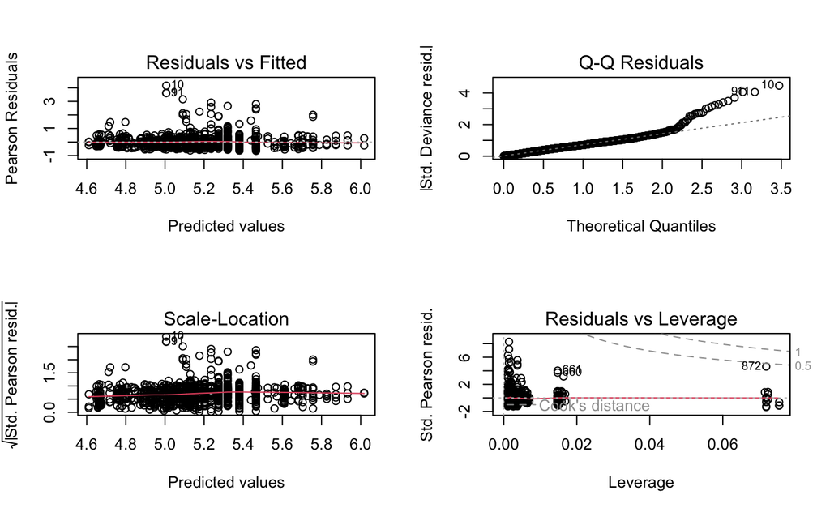

```r
glm1 <- glm(pricepn~log(distance)+accommodation_type, data=accom_q4, family = Gamma(link = "log"))
par(mfrow = c(2, 2))
plot(glm1)
```

```r
summary(glm1)
```

```
Call:
glm(formula = pricepn ~ log(distance) + accommodation_type, family = Gamma(link = "log"),
    data = accom_q4)

Coefficients:
                              Estimate Std. Error t value Pr(>|t|)
(Intercept)                    5.68205    0.06112  92.959  < 2e-16 ***
log(distance)                 -0.20861    0.01570 -13.288  < 2e-16 ***
accommodation_typeGuest House -0.40773    0.14784  -2.758  0.00593 **
accommodation_typeHotel       -0.55293    0.06344  -8.716  < 2e-16 ***
---
Signif. codes:  0 ‘***’ 0.001 ‘**’ 0.01 ‘*’ 0.05 ‘.’ 0.1 ‘ ’ 1

(Dispersion parameter for Gamma family taken to be 0.2537298)

    Null deviance: 229.95  on 968  degrees of freedom
Residual deviance: 162.26  on 965  degrees of freedom
AIC: 10907

Number of Fisher Scoring iterations: 4
```

*This is not a final model- we are struggling to decide whether to use log distance due to prediction values we recieve for high pricepn values- we might have to remove these extreme cases

part b: Comment on whether the distance of the accommodation from the city center is important in determining the price?

Should we just fit the model with just distance?- whether we do this or not, distance is significant in determining the price

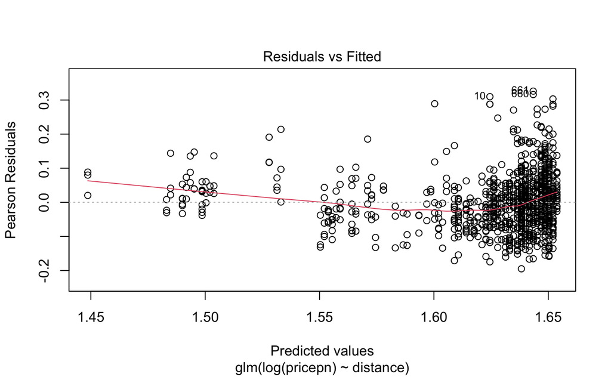

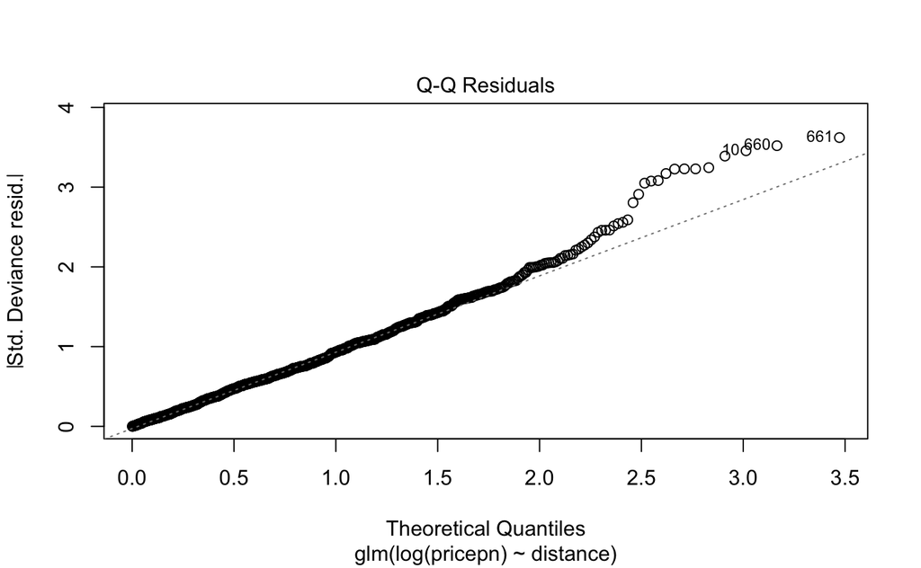

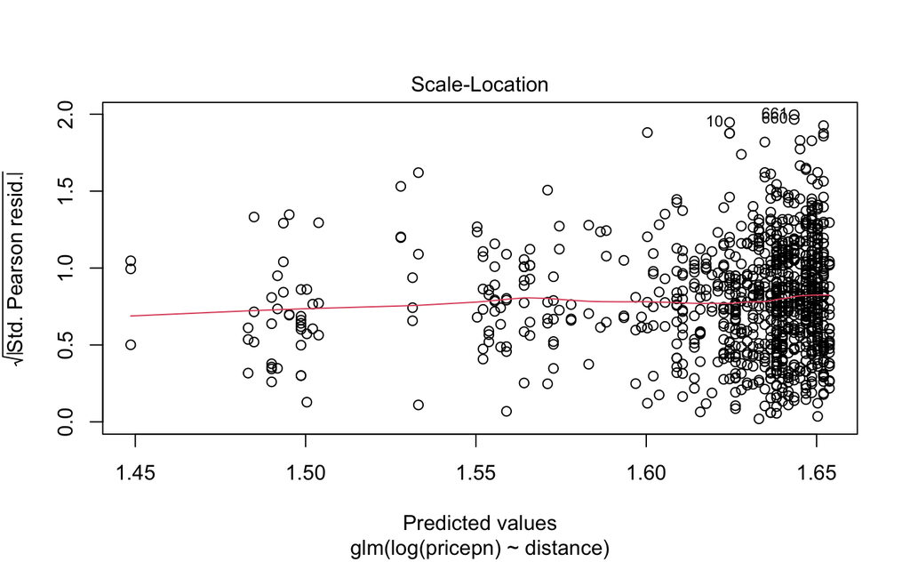

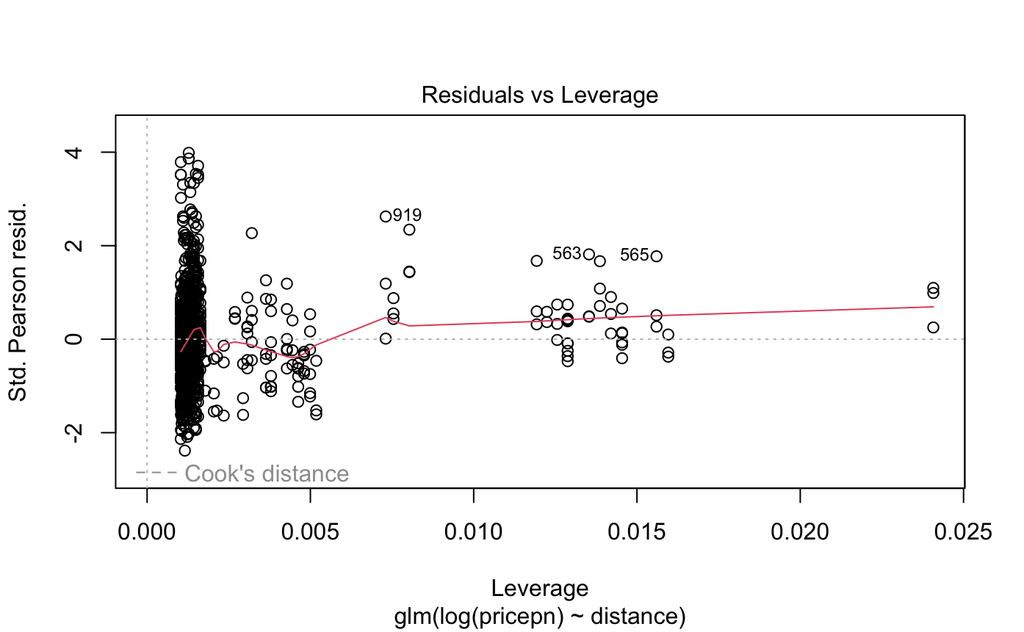

```r
glm2 = glm(log(pricepn)~distance, data=accom_q4, family = Gamma(link = "log"))
plot(glm2)
```

```r
summary(glm2)
```

```
Call:
glm(formula = log(pricepn) ~ distance, family = Gamma(link = "log"),
    data = accom_q4)

Coefficients:
             Estimate Std. Error t value Pr(>|t|)
(Intercept)  1.655494   0.003380  489.80   <2e-16 ***
distance    -0.017237   0.001212  -14.22   <2e-16 ***
---
Signif. codes:  0 ‘***’ 0.001 ‘**’ 0.01 ‘*’ 0.05 ‘.’ 0.1 ‘ ’ 1

(Dispersion parameter for Gamma family taken to be 0.006697069)

    Null deviance: 7.6143  on 968  degrees of freedom
Residual deviance: 6.2705  on 967  degrees of freedom
AIC: 1016.3

Number of Fisher Scoring iterations: 4
```

part c: How do the prices vary according to the accommodation type?

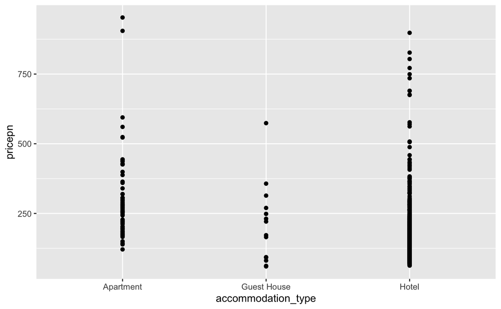

```r
ggplot(data=accom_q4, aes(x=accommodation_type, y=pricepn)) + geom_point()
```

^Just a quick plot- probably should just use our model to comment on this

part d: Are there any neighbourhoods which offer better price for the customers?

```r
ggplot(data=accom_q4, aes(x=neighbourhood2, y=pricepn, colour=offer_cat)) + geom_point() + theme(axis.text.x = element_text(angle = 45, hjust = 1))
```

[output not shown]

part e: Predict the weekday “Hotel” prices in Paris using the fitted GLM.